# Meteorological data timeseries analysis with python

This is the meteorological data timeseries analysis jupyter notebook sample. It based on Pandas dataframes, numpy, scipy and plotly python libraries. The creator of the notebook: MMath, Egor Zamotaev (e-mail: egor.zamotaev@mail.ru).

## Part 1. Basic meteorological data timeseries analysis

Download dataset from this link (registration is needed): http://meteo.ru/data/162-temperature-precipitation

### Data preparations

```python
# Import all libraries
import pandas as pd
import numpy as np
from scipy import stats
from scipy.fftpack import fft, fftfreq
import scipy as sp
from datetime import datetime
```

```python
import plotly.offline as py
import plotly.tools as tls
import plotly.graph_objs as go
import plotly.figure_factory as ff
py.init_notebook_mode(connected=True)
```

```python
# Declare functions
def getT():
    return ["TemperatureMin", "Temperature", "TemperatureMax"]
def getP():
    return ["Precipitation"]

# Get data from file
f = open("28698.txt","r")
data = [["Station Idx","Year","Month","Day","Quality","TemperatureMin", "Temperature", "TemperatureMax", "Precipitation"]]
for lines in f:
    rowData = lines.replace("\n","").replace(" ","").split(";")
    lst = []
    for s in rowData:
        d = 0
        try:
            d = float(s)
        except Exception:
            # OOps
            d
        lst.append(d)
    data.append(lst)

cols = 9
rows = len(data)

# Transform data to pandas df
headers = data.pop(0) # gives the headers as list and leaves data
df = pd.DataFrame(data, columns = headers)
date = pd.DataFrame(pd.to_datetime(df.Year*10000+df.Month*100+df.Day,format='%Y%m%d'), columns=["Date"])
df = df.drop(["Year","Month","Day"],axis=1)
df.insert(1,"Date",date)
df = df.set_index("Date")
df = df.dropna()

# draw Temperature and Precipitation graphics
layout = go.Layout(
    title="Temperature data daily changes",
    xaxis=dict(title = "Date", type='date'),
    yaxis=dict(title = "Day Temperature, °C"),
)
temperatureTraces = []
temperatureTraces.append(go.Scatter(x = df.index, y=df["TemperatureMin"], name = "Min"))
temperatureTraces.append(go.Scatter(x = df.index, y=df["Temperature"], name = "Ave"))
temperatureTraces.append(go.Scatter(x = df.index, y=df["TemperatureMax"], name = "Max"))
fig = go.Figure(data=temperatureTraces, layout=layout)
py.iplot(fig)
```

[interactive chart not shown]

### Yearly mean temperature dynamics

```python
data = df[getT()].resample("Y").mean()
layout = go.Layout(
    title="Temperature data yearly changes",
    xaxis=dict(title = "Date", type='date'),
    yaxis=dict(title = "Yearly mean temperature, °C"),
)
trace1 = go.Scatter(x = data.index, y=data["TemperatureMin"], name = "Min")
trace2 = go.Scatter(x = data.index, y=data["Temperature"], name = "Ave")
trace3 = go.Scatter(x = data.index, y=data["TemperatureMax"], name = "Max")
fig = go.Figure(data=[trace1,trace2,trace3], layout=layout)
py.iplot(fig)
```

[interactive chart not shown]

Maybe there is a trend but it hard to see without averaging.

### Yearly precipitation sum dynamics

```python
data = df[getP()].resample("Y").sum()
layout = go.Layout(
    title="Precipitation sum data yearly changes",
    xaxis=dict(title = "Date", type='date'),
    yaxis=dict(title = "Yearly Precipitation Sum, mm"),
)
trace = go.Scatter(x = data.index, y=data["Precipitation"])
fig = go.Figure(data=[trace], layout=layout)
py.iplot(fig)
```

[interactive chart not shown]

The same stuff as on graphic above... Needs to smoothed.

### Temperature and precipitation sum data monthly changes

```python
print("Temperature data monthly changes\n\n", df[getT()].resample("M").mean().dropna())
print("\n\nPrecipitation sum data monthly changes\n\n", df[getP()].resample("M").sum())
```

```
Temperature data monthly changes

             TemperatureMin  Temperature  TemperatureMax
Date
1950-01-31      -27.853333   -23.153333      -18.306667
1950-02-28      -22.107143   -17.892857      -13.753571
1950-03-31      -14.676667    -9.606667       -4.326667
1950-04-30       -1.790000     1.790000        6.596667
1950-05-31        5.563333    10.826667       17.173333
1950-06-30       11.156667    17.050000       23.016667
1950-07-31       13.003333    18.900000       24.780000
1950-08-31       10.633333    15.976667       21.773333
1950-09-30        7.743333    11.783333       17.346667
1950-10-31       -2.453333     1.926667        7.106667
1950-11-30      -17.896667   -13.410000       -8.796667
1951-01-31      -24.453333   -19.650000      -15.316667
1951-02-28      -31.396429   -26.671429      -21.225000
1951-03-31      -11.873333    -7.403333       -1.986667
1951-04-30        0.710000     7.880000       15.813333
1951-05-31        5.946667    12.470000       19.480000
1951-06-30        9.613333    16.480000       22.803333
1951-07-31       13.896667    20.776667       27.173333
1951-08-31        8.776667    15.736667       22.666667
1951-09-30        6.640000    13.773333       22.033333
1951-10-31       -2.276667     1.003333        5.240000
1951-11-30      -14.176667    -9.726667       -5.583333
1952-01-31      -21.120000   -16.363333      -11.516667
1952-02-29      -24.313793   -19.734483      -14.134483
1952-03-31      -19.570000   -14.093333       -8.403333
1952-04-30       -6.053333    -1.543333        3.530000
1952-05-31        4.670000    13.160000       20.610000
1952-06-30       10.006667    18.640000       26.040000
1952-07-31       14.413333    22.416667       29.226667
1952-08-31       11.220000    17.786667       25.293333
...                    ...          ...             ...
2015-04-30        0.623333     5.463333       10.773333
2015-05-31        7.516667    13.823333       20.240000
2015-06-30       13.816667    20.183333       26.186667
2015-07-31       13.330000    18.460000       23.743333
2015-08-31       10.960000    15.233333       20.160000
```

[output cut: 81 more lines]

```
2016-11-30           38.3
2016-12-31            0.0
2017-01-31           24.3
2017-02-28           19.8
2017-03-31           14.9
2017-04-30           22.3
2017-05-31           23.4
2017-06-30           31.6
2017-07-31           70.4
2017-08-31            9.6
2017-09-30           29.1
2017-10-31           42.4
2017-11-30           22.0

[815 rows x 1 columns]
```

Oh, it's so hard to understand table data. Better to see the once.

### Rolling year-decade mean temperature and precipitation sum

```python
data = df[["Temperature"]].resample("Y").mean().rolling(10, min_periods=10).mean().dropna()

# Estimate trend
temperature = data["Temperature"].tolist()
idx = np.arange(0,len(temperature))
slope, intercept, r_value, p_value, std_err = stats.linregress(idx,temperature)
line = slope * idx + intercept

# Draw
layout = go.Layout(
    title="Year-decade mean rolling temperature. Increases by " + str(round(slope,2)) + "°C/Year",
    xaxis=dict(title = "Date", type='date'),
    yaxis=dict(title = "Temperature, °C"),
)
trace1 = go.Scatter(x = data.index, y=data["Temperature"], name="Data")
trace2 = go.Scatter(x = data.index, y=line, name='Trend')
fig = go.Figure(data=[trace1,trace2], layout=layout)
py.iplot(fig)



# The same for hummidity sum
data = df[getP()].resample("Y").sum().rolling(10, min_periods=10).mean().dropna()

# Estimate trend
precipitation = data["Precipitation"].tolist()
idx = np.arange(0,len(precipitation))
slope, intercept, r_value, p_value, std_err = stats.linregress(idx,precipitation)
line = slope * idx + intercept

# Draw
layout = go.Layout(
    title="Year-decade mean rolling precipitation sum. \nIncreases by " + str(round(slope,2)) + "mm/Year",
    xaxis=dict(title = "Date", type='date'),
    yaxis=dict(title = "Precipitation Sum, mm"),
)
trace1 = go.Scatter(x = data.index, y=data["Precipitation"], name="Data")
trace2 = go.Scatter(x = data.index, y=line, name='Trend')
fig = go.Figure(data=[trace1,trace2], layout=layout)
py.iplot(fig)
```

[interactive chart not shown]

As we can see on the graphs, there are sufficient trends to increase temperature and precipitation for last 50 years. Unfortinately, we can't understand the nature of this trends, we can only to hypothesize...

### Chain increase temp for temperatures

```python
data = df[["Temperature"]].resample("M").mean().dropna()
data = (data - data.shift(1)).dropna()

# Draw
layout = go.Layout(
    title="Chain increase temp for temperatures",
    xaxis=dict(title = "Date", type='date'),
    yaxis=dict(title = "Chain increase temp temerature, °C"),
)
trace = go.Scatter(x = data.index, y=data["Temperature"])
fig = go.Figure(data=[trace], layout=layout)
py.iplot(fig)

# Get frequencies
midTemperature = data["Temperature"].tolist()
data = abs(sp.fft(midTemperature))
half = int(len(data)/2)
data = data[:half]
data /= max(data)
frequencies = fftfreq(len(midTemperature)) * 12

# Draw
layout = go.Layout(
    title="Chain increase temp spectre for temperatures",
    xaxis=dict(title = "Frequency (per 1 year)"),
    yaxis=dict(title = "Chain increase temp normalized magnitude"),
)
trace = go.Scatter(x = frequencies, y=data)
fig = go.Figure(data=[trace], layout=layout)
py.iplot(fig)
```

[interactive chart not shown]

As we can see there are two main periods: one year and half year. First is the common Earth - Solar movement cycle, and second - it's a question for me... I don't know and may only suppose. So, we can see near 3 and 4 fluctuation/per year subdominant cycles. Maybe it's also connected with cosmic cycle or maybe it connected with Earth hemispheres inner climate, ocean cycles, etc. I need to read more about it.

### Chain increase temp for precipitation sum

```python
data = df[["Precipitation"]].resample("M").sum().dropna()
data = (data - data.shift(1)).dropna()

# Draw
layout = go.Layout(
    title="Dynamics of chain increase temp for precipitation sum",
    xaxis=dict(title = "Date", type='date'),
    yaxis=dict(title = "Chain increase temp of precipitation sum, mm"),
)
trace = go.Scatter(x = data.index, y=data["Precipitation"])
fig = go.Figure(data=[trace], layout=layout)
py.iplot(fig)

# Get frequencies
midPrecipitation = data["Precipitation"].tolist()
data = abs(sp.fft(midPrecipitation))
half = int(len(data)/2)
data = data[:half]
data /= max(data)
frequencies = fftfreq(len(midPrecipitation)) * 12

# Draw
layout = go.Layout(
    title="Chain increase temp spectrum for precipitation sum",
    xaxis=dict(title = "Frequency (per 1 year)"),
    yaxis=dict(title = "Precipitation sum chain increase temp normalized magnitude"),
)
trace = go.Scatter(x = frequencies, y=data)
fig = go.Figure(data=[trace], layout=layout)
py.iplot(fig)
```

[interactive chart not shown]

The picture is rather more interesting than the picture for temperature cause we have clear 1, 2, 3, 4, 5 and 5.4, 5.8, 6 cycles. And if the first pair we can be easily explained, the next ones - it's riddle.

### Days of sustainable temerature transition over the 0°C

Algorithm explanation: http://aisori.meteo.ru/AisoriHelp/Part_2.htm

```python
def day0(x):
    periods = []
    i = 0
    n = len(x) - 1
    while i < n:

        period = []
        while i < n:
            if x[i] >= 0:
                period.append(x[i])
                i += 1
            else:
                break
        if len(period) > 0:
            periods.append(period)

        period = []
        while i < n:
            if x[i] < 0:
                period.append(x[i])
                i += 1
            else:
                break
        if len(period) > 0:
            periods.append(period)

    # we have periods, next we can find the next one with positive sum > negative sum
    sums = []
    for i in range(0,len(periods)):
        sums.append(sum(periods[i]))

    # search spring day 0 temperature transition
    springDay0 = x.index[0]
    i = 0
    while i < len(sums):
        if(sums[i] < 0):
            i += 1
        else:
            finded = True
            for j in range(i + 1, len(sums)):
                if sums[j] < 0 and abs(sums[j]) > sums[i]:
                    finded = False
            if finded:
                dayIdx = 0
                for j in range(0, i):
                    dayIdx += len(periods[j])
                springDay0 = x.index[dayIdx]
                break
            else:
                i += 1

    # the same stuff for autumn
    autumnDay0 = x.index[0]
    while i < len(sums):
        if(sums[i] > 0):
            i += 1
        else:
            finded = True
            for j in range(i + 1, len(sums)):
                if sums[j] > 0 and sums[j] > abs(sums[i]):
                    finded = False
            if finded:
                dayIdx = 0
                for j in range(0, i):
                    dayIdx += len(periods[j])
                autumnDay0 = x.index[dayIdx]
                break
            else:
                i += 1

    return [springDay0, autumnDay0]

def dateToNthDay(date, format='%Y-%m-%d %h:%m:%s'):
    date = pd.to_datetime(date, format=format)
    new_year_day = pd.Timestamp(year=date.year, month=1, day=1)
    return (date - new_year_day).days + 1

def dayN(x, type = 0):
    return dateToNthDay(x[0][type])

data = df[["Temperature"]].resample("Y")
# data = data.agg([("day0",lambda x: day0(x))])
data = data.apply(day0)
data = data.rename(index=str,columns={"Temperature":"DaysDates"})
data["DaySpring"]=data.apply(lambda x: dayN(x),axis = 1)
data["DayAutumn"]=data.apply(lambda x: dayN(x, 1),axis = 1)
data["DayDiff"]=data["DayAutumn"] - data["DaySpring"]
# data.index = [s[0:4] for s in data.index.tolist()]
data = data.drop(columns=["DaysDates"],axis=1)
data = data.rolling(10, min_periods=10).mean().dropna()
data

# Draw
layout = go.Layout(
    title="Days of sustainable temperature transition over 0°C dynamics (Spring)",
    xaxis=dict(title = "Year"),
    yaxis=dict(title = "Day Number in the Year"),
)
trace = go.Scatter(x = data.index, y=data["DaySpring"])
fig = go.Figure(data=[trace], layout=layout)
py.iplot(fig)
#
layout = go.Layout(
    title="Days of sustainable temperature transition over 0°C dynamics (Autumn)",
    xaxis=dict(title = "Year"),
    yaxis=dict(title = "Day Number in the Year"),
)
trace = go.Scatter(x = data.index, y=data["DayAutumn"])
fig = go.Figure(data=[trace], layout=layout)
py.iplot(fig)
#
layout = go.Layout(
    title="Spring-Autumn Season Length (between two sustainable temperature transitions over 0°C)",
    xaxis=dict(title = "Year"),
    yaxis=dict(title = "Days"),
)
trace = go.Scatter(x = data.index, y=data["DayDiff"])
fig = go.Figure(data=[trace], layout=layout)
py.iplot(fig)
```

[interactive chart not shown]

Hm, it's looks very interesting!! As you can see Autumn-Spring Season Lenght is increase!!! Difference between last and first values equals nearly month!!! It's amazing!! But why that is happens?? Main increasing connected with early Spring start. Do you think it is a human activity so had an impact?

## Part 2. Statistical analysis of meteorological dataset

### Descriptive statistics

```python
def describe(df, stats = ["var", "skew", "kurt", "mad"]):
    d = df.describe()
    d = d.append(df.reindex(axis=1).agg(stats))
    s = d.loc["max",:] - d.loc["min",:]
    s.name = "R"
    d = d.append(s)
    s = d.loc["R",:]/d.loc["mean",:]
    s.name = "R/mean"
    d=d.append(s)
    d = d.drop(["25%","50%", "75%"],axis=0)
    return d
```

```python
def describeAllset(df):
    data = df[["Temperature"] + getP()]
    data["Temperature Temp"] = data["Temperature"] - data["Temperature"].shift(1)
    data = data.dropna()[["Temperature","Temperature Temp", "Precipitation"]]
    d = describe(data)
#     d.loc["R/mean","Temperature Temp"]=""

    precipitationMonth = data["Precipitation"].resample("M")
    precipitationMonthSum = precipitationMonth.sum()
    precipitationMonthSum.name = "PrecipitationSumMonth"
    precipitationData = pd.DataFrame(precipitationMonthSum)
    def precipitation0Day(x):
        maxDays = 0
        nowDays = 0
        for i in x:
            if i == 0:
                nowDays += 1
                if nowDays > maxDays:
                    maxDays = nowDays
            else:
                nowDays = 0
        return maxDays
    precipitation0Days = precipitationMonth.apply(precipitation0Day)
    precipitationData["Precipitation0Days"]= precipitation0Days
    p = describe(precipitationData)

    result = pd.concat([d,p],axis=1)
    return result
```

```python
allstat = describeAllset(df)
allstat
```

|  | Temperature | Temperature Temp | Precipitation | PrecipitationSumMonth | Precipitation0Days |
| --- | --- | --- | --- | --- | --- |
| count | 22320.000000 | 22320.000000 | 22320.000000 | 815.000000 | 815.000000 |
| mean | 3.083571 | 0.000470 | 1.093105 | 29.936319 | 7.235583 |
| std | 14.260119 | 3.846469 | 3.104758 | 26.428870 | 4.362106 |
| min | -39.800000 | -31.500000 | 0.000000 | 0.000000 | 0.000000 |
| max | 30.600000 | 19.900000 | 80.200000 | 173.300000 | 27.000000 |
| var | 203.350980 | 14.795323 | 9.639523 | 698.485190 | 19.027971 |
| skew | -0.467241 | -0.365282 | 6.944977 | 1.497042 | 0.779916 |
| kurt | -0.696376 | 2.748900 | 84.622066 | 2.790389 | 1.160499 |
| mad | 12.044685 | 2.804001 | 1.557212 | 19.921908 | 3.278299 |
| R | 70.400000 | 51.400000 | 80.200000 | 173.300000 | 27.000000 |
| R/mean | 22.830674 | 109261.714286 | 73.368992 | 5.788955 | 3.731558 |

#### First 10 years stats

```python
first10 = describeAllset(df[:3650])
first10
```

|  | Temperature | Temperature Temp | Precipitation | PrecipitationSumMonth | Precipitation0Days |
| --- | --- | --- | --- | --- | --- |
| count | 3649.000000 | 3649.000000 | 3649.000000 | 134.000000 | 134.000000 |
| mean | 1.685421 | 0.001644 | 0.894355 | 24.354478 | 7.708955 |
| std | 15.298859 | 4.049863 | 2.885538 | 25.814330 | 4.880257 |
| min | -38.600000 | -31.500000 | 0.000000 | 0.000000 | 0.000000 |
| max | 29.500000 | 18.600000 | 74.200000 | 173.300000 | 27.000000 |
| var | 234.055089 | 16.401390 | 8.326328 | 666.379641 | 23.816912 |
| skew | -0.419772 | -0.333591 | 8.895281 | 2.171548 | 1.035846 |
| kurt | -0.883799 | 2.780822 | 147.107317 | 7.783776 | 1.696639 |
| mad | 13.075142 | 2.945108 | 1.332204 | 18.669113 | 3.612052 |
| R | 68.100000 | 50.100000 | 74.200000 | 173.300000 | 27.000000 |
| R/mean | 40.405343 | 30469.150000 | 82.964854 | 7.115735 | 3.502420 |

#### Last 10 years stats

```python
last10 = describeAllset(df[-3650:])
last10
```

|  | Temperature | Temperature Temp | Precipitation | PrecipitationSumMonth | Precipitation0Days |
| --- | --- | --- | --- | --- | --- |
| count | 3649.000000 | 3649.000000 | 3649.000000 | 134.000000 | 134.000000 |
| mean | 3.855878 | -0.001891 | 1.210030 | 32.950746 | 6.917910 |
| std | 13.874998 | 3.662383 | 3.544102 | 28.508207 | 3.943298 |
| min | -34.600000 | -30.800000 | 0.000000 | 0.000000 | 0.000000 |
| max | 30.600000 | 14.600000 | 80.200000 | 154.900000 | 21.000000 |
| var | 192.515580 | 13.413053 | 12.560661 | 812.717857 | 15.549602 |
| skew | -0.530101 | -0.612731 | 7.763106 | 1.620131 | 0.560208 |
| kurt | -0.629072 | 4.216941 | 102.398442 | 3.418627 | 1.178269 |
| mad | 11.629113 | 2.669594 | 1.701999 | 21.021787 | 2.925262 |
| R | 65.200000 | 45.400000 | 80.200000 | 154.900000 | 21.000000 |
| R/mean | 16.909247 | -24009.362319 | 66.279340 | 4.700956 | 3.035599 |

```python
dif = last10.sub(first10)
dif = dif.drop("count")
dif = dif.drop(["var","skew","kurt","mad","R","R/mean"])
dif = dif.drop(columns=["Precipitation0Days"],axis=1)

def orange(val):
    color = 'orange'
    return 'background-color: %s' % color
def blue(val):
    color = 'cyan'
    return 'background-color: %s' % color
dif.style.applymap(orange,subset=pd.IndexSlice["mean","Temperature"])\
         .applymap(orange,subset=pd.IndexSlice["min":"max","Temperature"])\
         .applymap(blue,subset=pd.IndexSlice["mean","PrecipitationSumMonth"])
```

|  | Temperature | Temperature Temp | Precipitation | PrecipitationSumMonth |
| --- | --- | --- | --- | --- |
| mean | 2.17046 | -0.00353522 | 0.315676 | 8.59627 |
| std | -1.42386 | -0.387479 | 0.658565 | 2.69388 |
| min | 4 | 0.7 | 0 | 0 |
| max | 1.1 | -4 | 6 | -18.4 |

#### T-test of difference significance

```python
# Temperature
result = stats.ttest_ind(df[:3650]["Temperature"],first10[-3650:]["Temperature"])
print(result)
if(result[1] < 0.01):
    print("\nTemperature changes by {:.2}°C at the last 50 years is significant!".format(dif.loc["mean", "Temperature"]))
```

[output not shown]

```python
# Precipitation
result = stats.ttest_ind(df[:3650]["Precipitation"],first10[-3650:]["Precipitation"])
print(result)
if(result[1] < 0.01):
    print("\nPrecipitation changes by {:.2} mm at the last 50 years is significant!".format(dif.loc["mean", "Precipitation"]))
```

[output not shown]

### Empiric probability density functions estimation

```python
import warnings
import numpy as np
import pandas as pd
import scipy.stats as st
import statsmodels as sm
import matplotlib
import matplotlib.pyplot as plt

warnings.filterwarnings("ignore")

matplotlib.rcParams['figure.figsize'] = (16.0, 12.0)
matplotlib.style.use('ggplot')

# Create models from data
def best_fit_distribution(data, bins=200, ax=None):
    """Model data by finding best fit distribution to data"""
    # Get histogram of original data
    y, x = np.histogram(data, bins=bins, density=True)
    x = (x + np.roll(x, -1))[:-1] / 2.0

    # Distributions to check
#     DISTRIBUTIONS = [
#         st.alpha,st.anglit,st.arcsine,st.beta,st.betaprime,st.bradford,st.burr,st.cauchy,st.chi,st.chi2,st.cosine,
#         st.dgamma,st.dweibull,st.erlang,st.expon,st.exponnorm,st.exponweib,st.exponpow,st.f,st.fatiguelife,st.fisk,
#         st.foldcauchy,st.foldnorm,st.frechet_r,st.frechet_l,st.genlogistic,st.genpareto,st.gennorm,st.genexpon,
#         st.genextreme,st.gausshyper,st.gamma,st.gengamma,st.genhalflogistic,st.gilbrat,st.gompertz,st.gumbel_r,
#         st.gumbel_l,st.halfcauchy,st.halflogistic,st.halfnorm,st.halfgennorm,st.hypsecant,st.invgamma,st.invgauss,
#         st.invweibull,st.johnsonsb,st.johnsonsu,st.ksone,st.kstwobign,st.laplace,st.levy,st.levy_l,st.levy_stable,
#         st.logistic,st.loggamma,st.loglaplace,st.lognorm,st.lomax,st.maxwell,st.mielke,st.nakagami,st.ncx2,st.ncf,
#         st.nct,st.norm,st.pareto,st.pearson3,st.powerlaw,st.powerlognorm,st.powernorm,st.rdist,st.reciprocal,
#         st.rayleigh,st.rice,st.recipinvgauss,st.semicircular,st.t,st.triang,st.truncexpon,st.truncnorm,st.tukeylambda,
#         st.uniform,st.vonmises,st.vonmises_line,st.wald,st.weibull_min,st.weibull_max,st.wrapcauchy
#     ]
    DISTRIBUTIONS = [
        st.norm, st.expon, st.uniform, st.johnsonsb, st.laplace, st.rayleigh, st.beta
    ]

    # Best holders
    best_distribution = st.norm
    best_params = (0.0, 1.0)
    best_sse = np.inf

    # Estimate distribution parameters from data
    for distribution in DISTRIBUTIONS:

        # Try to fit the distribution
        try:
            # Ignore warnings from data that can't be fit
            with warnings.catch_warnings():
                warnings.filterwarnings('ignore')

                # fit dist to data
                params = distribution.fit(data)

                # Separate parts of parameters
                arg = params[:-2]
                loc = params[-2]
                scale = params[-1]

                # Calculate fitted PDF and error with fit in distribution
                pdf = distribution.pdf(x, loc=loc, scale=scale, *arg)
                sse = np.sum(np.power(y - pdf, 2.0))

                # if axis pass in add to plot
                try:
                    if ax:
                        pd.Series(pdf, x).plot(ax=ax)
                    end
                except Exception:
                    pass

                # identify if this distribution is better
                if best_sse > sse > 0:
                    best_distribution = distribution
                    best_params = params
                    best_sse = sse

        except Exception:
            pass

    return (best_distribution.name, best_params)

def make_pdf(dist, params, size=10000):
    """Generate distributions's Probability Distribution Function """

    # Separate parts of parameters
    arg = params[:-2]
    loc = params[-2]
    scale = params[-1]

    # Get sane start and end points of distribution
    start = dist.ppf(0.01, *arg, loc=loc, scale=scale) if arg else dist.ppf(0.01, loc=loc, scale=scale)
    end = dist.ppf(0.99, *arg, loc=loc, scale=scale) if arg else dist.ppf(0.99, loc=loc, scale=scale)

    # Build PDF and turn into pandas Series
    x = np.linspace(start, end, size)
    y = dist.pdf(x, loc=loc, scale=scale, *arg)
    pdf = pd.Series(y, x)

    return pdf

def drawBestFitPDF(data):
    best_fit_name, best_fit_params = best_fit_distribution(data, 20)
    best_dist = getattr(st, best_fit_name)
    print("The nearest distribution type is", best_fit_name)

    # Make PDF with best params
    pdf = make_pdf(best_dist, best_fit_params, 200)

    # Display
    plt.figure(figsize=(12,8))
    ax = pdf.plot(lw=2, label='PDF', legend=True)
    data.plot(kind='hist', bins=20, density=True, alpha=0.5, label='Data', legend=True, ax=ax)
```

#### For all time

```
The nearest distribution type is johnsonsb
```

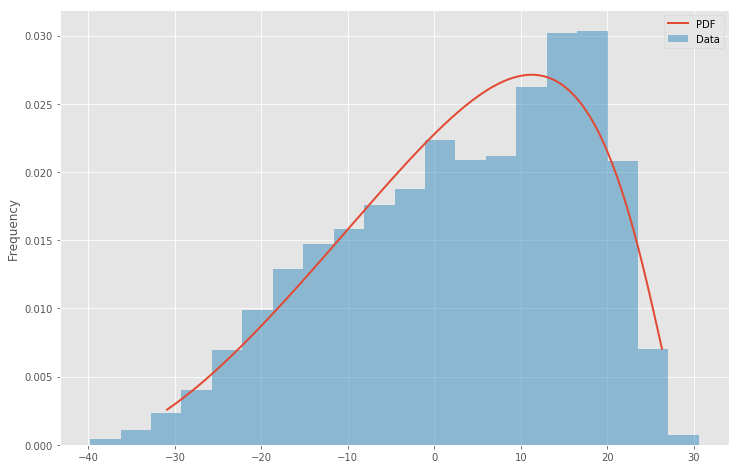

```python
drawBestFitPDF(df["Temperature"])
```

```
The nearest distribution type is rayleigh
```

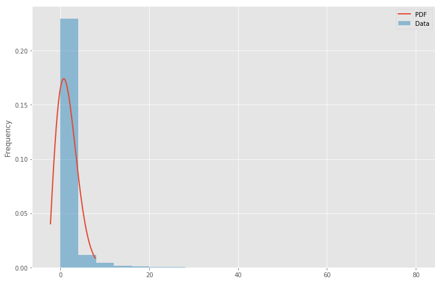

```python
drawBestFitPDF(df["Precipitation"])
```

```python
# prepare another data
acit = pd.DataFrame(df["Temperature"] - df["Temperature"].shift(1))
acit = acit.dropna()
hsum = pd.DataFrame(df["Precipitation"].resample("M").sum())
```

```
The nearest distribution type is laplace
```

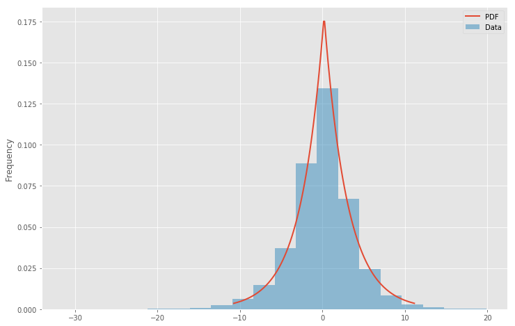

```python
drawBestFitPDF(acit["Temperature"])
```

```
The nearest distribution type is johnsonsb
```

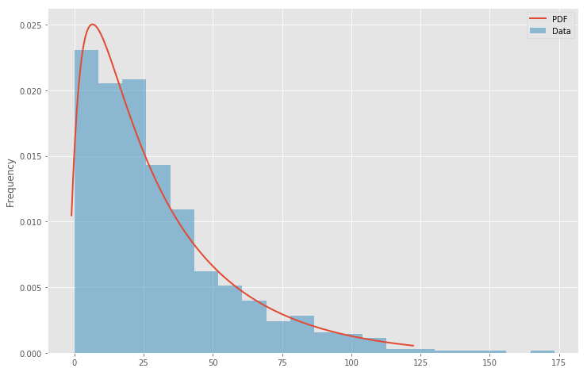

```python
drawBestFitPDF(hsum["Precipitation"])
```

#### First 10 years

```
The nearest distribution type is beta
```

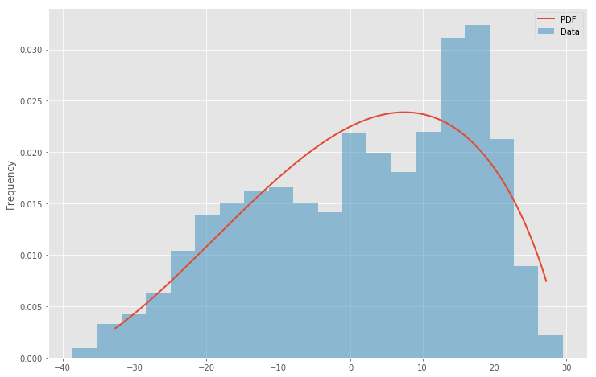

```python
drawBestFitPDF(df[:3650]["Temperature"])
```

```
The nearest distribution type is rayleigh
```

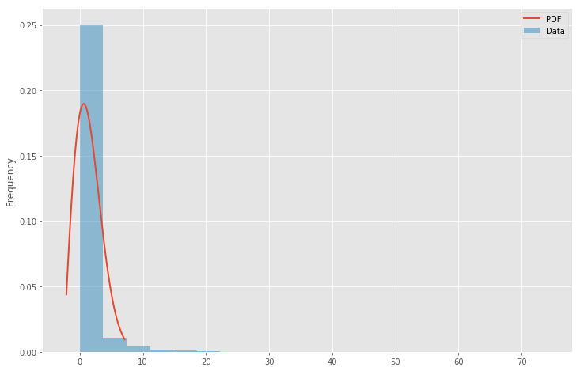

```python
drawBestFitPDF(df[:3650]["Precipitation"])
```

```
The nearest distribution type is laplace
```

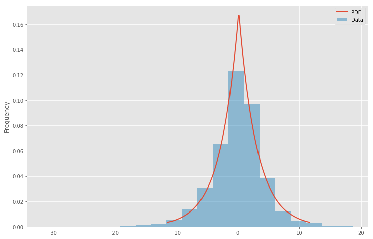

```python
drawBestFitPDF(acit[:3650]["Temperature"])
```

```
The nearest distribution type is expon
```

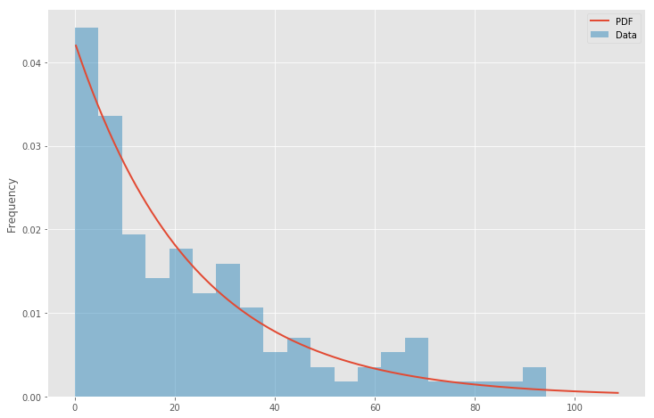

```python
drawBestFitPDF(hsum[:120]["Precipitation"])
```

#### Last 10 years

```
The nearest distribution type is beta
```

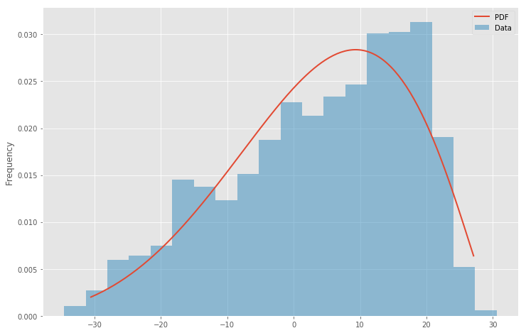

```python
drawBestFitPDF(df[-3650:]["Temperature"])
```

```
The nearest distribution type is expon
```

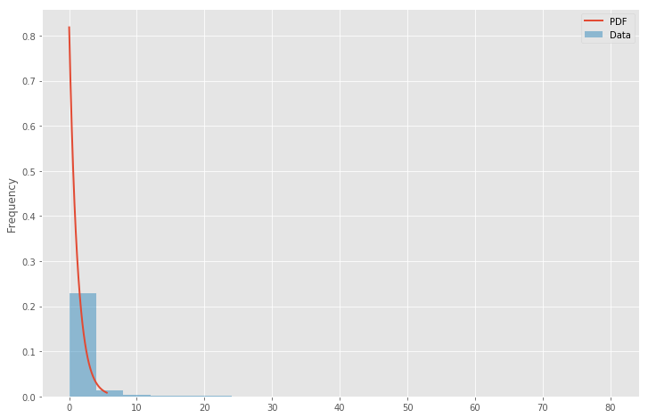

```python
drawBestFitPDF(df[-3650:]["Precipitation"])
```

```
The nearest distribution type is beta
```

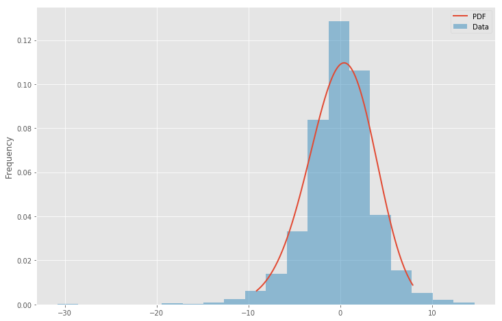

```python
drawBestFitPDF(acit[-3650:]["Temperature"])
```

```
The nearest distribution type is expon
```

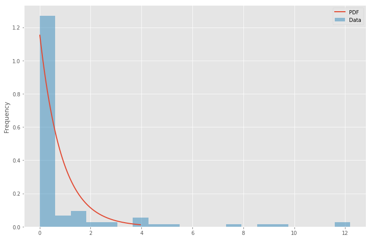

```python
drawBestFitPDF(df[-120:]["Precipitation"])
```

## Part 3. R/S analysis. Hurst exponent interpretation

More info at page: https://en.wikipedia.org/wiki/Hurst_exponent

```python
from hurst import compute_Hc

def calcHurstExponent(df):

    H, c, data = compute_Hc(df)

    # Plot
    f, ax = plt.subplots()
    ax.plot(data[0], c*data[0]**H, color="deepskyblue")
    ax.scatter(data[0], data[1], color="purple")
    ax.set_xscale('log')
    ax.set_yscale('log')
    ax.set_xlabel('Time interval')
    ax.set_ylabel('R/S ratio')
    ax.grid(True)
    plt.show()

    print("H={:.4f}, c={:.4f}".format(H,c))

    if H > 0.5:
        print("H > 0.5 therefore the process is persistent (memory/trend safe).")
        if H == 1:
            print("Also it is fully preditable.")
    elif H < 0.5:
        print("H < 0.5 therefore the process in antipersistent (stochastic).")
    else:
        print("H = 0.5 the godbless uncertainty!")
```

### Temperature

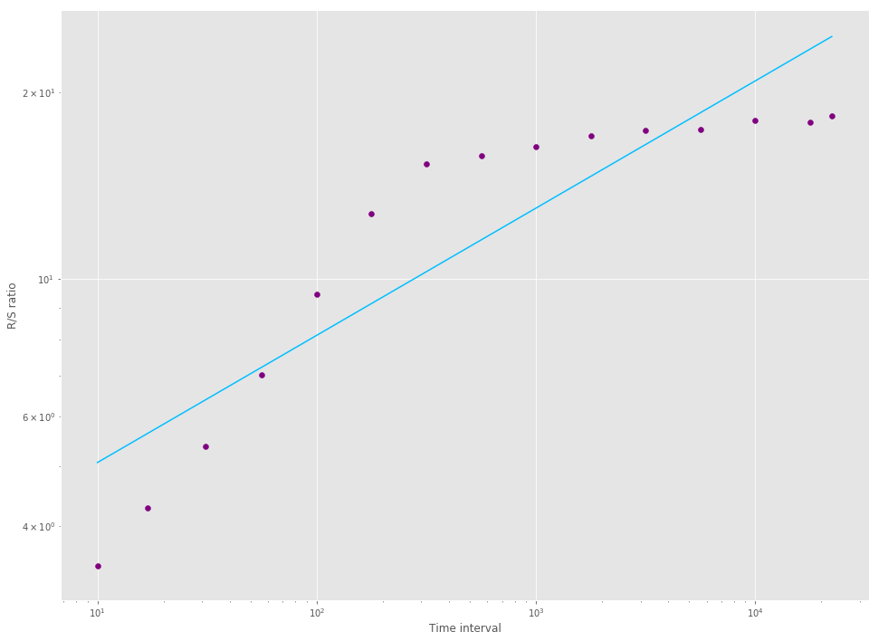

```
H=0.2049, c=3.1603
H < 0.5 therefore the process in antipersistent (stochastic).
```

```python
calcHurstExponent(df["Temperature"])
```

The daily temperature is unpredictable.

### Precipitation

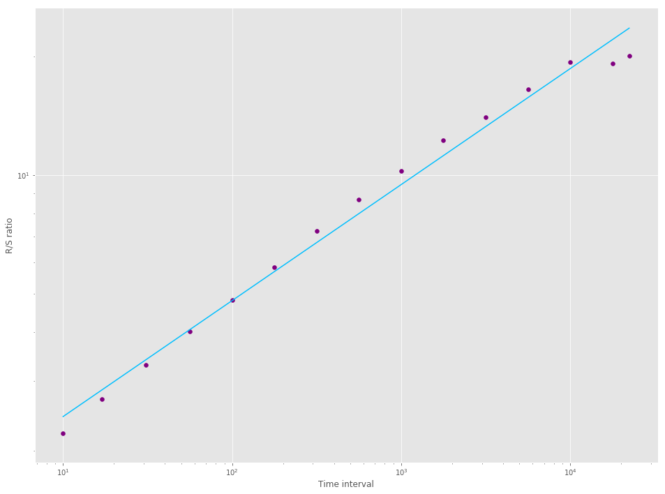

```
H=0.2942, c=1.2397
H < 0.5 therefore the process in antipersistent (stochastic).
```

```python
calcHurstExponent(df[getP()])
```

In other words the precipitation daily changes is not predictable. But we seen that precipitation sum have some trend. So, it is quite bit different processes!